```python
%autosave 60
```

```
Autosaving every 60 seconds
```

# Домашнее задание EDA | МТС Тета

- Нужно провести EDA любого датасета на ваше усмотрение в специально подготовленном ipynb
- В этом ноутбуке будут блоки под разные типы графиков
- Нужно выбрать такой датасет, который позволит построить каждый из этих графиков корректно
- В ноутбуке так же будет дополнительное поле для графика на ваш выбор. В нем должен быть график, который не был построен ранее в ноутбуке (другой тип графика)
- Ноутбук должен отбегать в режиме run all, а так же сохранять все изображения шаблонным образом, как заложено в ноутбуке
- Для каждого графика должны быть написаны выводы
- **Вместе с ноутбуком нужно сдать сохраненные изображения (проверьте корректность их сохранения перед отправкой ДЗ)**
- изображения должны быть в формате png или jpeg. Не сохраняйте изображения в html (так делает plotly)

**Критерии оценки**

- Вы построили все основные графики без критических ошибок – 8 баллов
- Вы выполнили пункт 1, а так же построили дополнительный график - 10 баллов
- Доп. баллы выставляются за победу в tinder игре – подробности будут позже. Но чтобы в ней победить, ваш график должен оказаться самым красивым.
- Доп. Баллы получат топ 10 человек итогового рейтинга.
- Максимум 10 баллов (и +5 дополнительных)
- 1-4 балла: незачет
- 5-6 баллов: 3, незачет
- 7-8 баллов: 4, зачет
- 9-10 баллов: 5, зачет

## Подготовка

```python
import os
import matplotlib.pyplot as plt
import seaborn as sns
import pandas as pd
import numpy as np
from sklearn.datasets import load_diabetes
import seaborn as sns
```

```python
# подставьте ваше имя и фамилию в эту переменную как в примере, (например Максим_Шаланкин)
image_name_prefix = 'Владимир_Смирнов'

# можно поменять, а можно оставить - сюда будут сохраняться изображения
path_to_save_images = 'C:\\Users\\smirn\\OneDrive\\Рабочий стол\\eda_1_jupiter_images'
```

```python
os.makedirs(path_to_save_images, exist_ok=True)
```

## Подготовка данных

### Credit Risk Analysis for extending Bank Loans

[Link](https://www.kaggle.com/datasets/atulmittal199174/credit-risk-analysis-for-extending-bank-loans)

Нет описания к данным, но датасет показался мне достаточно интересным. Учитывая контекст задания, придумаю собственные полные описания переменных:

| Колонка | Полное название | Описание |
| --- | --- | --- |
| **age** | Age of the Customers | Возраст клиента в годах на момент подачи заявки |
| **ed** | Education Level | Уровень образования клиента (1, 2, 3, 4, 5) |
| **employ** | Work Experience | Количество лет трудового стажа клиента |
| **address** | Address of the Customer | Количество лет проживания клиента по текущему адресу |
| **income** | Yearly Income of the Customer | Годовой доход клиента (в тысячах долларов или другой валюте) |
| **debtinc** | Debt to Income Ratio | Соотношение общей суммы долга к годовому доходу (в процентах) |
| **creddebt** | Credit to Debt Ratio | Сумма задолженности по кредитным картам относительно общего долга |
| **othdebt** | Other Debts | Сумма других долгов, таких как ипотека или автокредит |
| **default** | Customer Defaulted in the Past (1 = defaulted, 0 = Never Defaulted) | Факт дефолта: 1 – клиент допускал дефолт, 0 – не допускал |

```python
# Загружаю данные
df = pd.read_csv('bankloans.csv')
df
```

|  | age | ed | employ | address | income | debtinc | creddebt | othdebt | default |
| --- | --- | --- | --- | --- | --- | --- | --- | --- | --- |
| 0 | 41 | 3 | 17 | 12 | 176 | 9.3 | 11.359392 | 5.008608 | 1.0 |
| 1 | 27 | 1 | 10 | 6 | 31 | 17.3 | 1.362202 | 4.000798 | 0.0 |
| 2 | 40 | 1 | 15 | 14 | 55 | 5.5 | 0.856075 | 2.168925 | 0.0 |
| 3 | 41 | 1 | 15 | 14 | 120 | 2.9 | 2.658720 | 0.821280 | 0.0 |
| 4 | 24 | 2 | 2 | 0 | 28 | 17.3 | 1.787436 | 3.056564 | 1.0 |
| ... | ... | ... | ... | ... | ... | ... | ... | ... | ... |
| 1145 | 34 | 1 | 12 | 15 | 32 | 2.7 | 0.239328 | 0.624672 | NaN |
| 1146 | 32 | 2 | 12 | 11 | 116 | 5.7 | 4.026708 | 2.585292 | NaN |
| 1147 | 48 | 1 | 13 | 11 | 38 | 10.8 | 0.722304 | 3.381696 | NaN |
| 1148 | 35 | 2 | 1 | 11 | 24 | 7.8 | 0.417456 | 1.454544 | NaN |
| 1149 | 37 | 1 | 20 | 13 | 41 | 12.9 | 0.899130 | 4.389870 | NaN |

1150 rows × 9 columns

```python
df.describe()
```

|  | age | ed | employ | address | income | debtinc | creddebt | othdebt | default |
| --- | --- | --- | --- | --- | --- | --- | --- | --- | --- |
| count | 1150.000000 | 1150.000000 | 1150.000000 | 1150.000000 | 1150.000000 | 1150.000000 | 1150.000000 | 1150.000000 | 700.000000 |
| mean | 35.235652 | 1.695652 | 8.781739 | 8.485217 | 47.982609 | 10.063391 | 1.605111 | 3.103844 | 0.261429 |
| std | 8.089961 | 0.927051 | 6.914762 | 6.977725 | 40.508814 | 6.584288 | 2.135967 | 3.529273 | 0.439727 |
| min | 20.000000 | 1.000000 | 0.000000 | 0.000000 | 13.000000 | 0.100000 | 0.011696 | 0.045584 | 0.000000 |
| 25% | 29.000000 | 1.000000 | 3.000000 | 3.000000 | 24.000000 | 5.200000 | 0.415584 | 1.047996 | 0.000000 |
| 50% | 35.000000 | 1.000000 | 7.000000 | 7.000000 | 36.000000 | 8.750000 | 0.899130 | 2.038053 | 0.000000 |
| 75% | 41.000000 | 2.000000 | 13.000000 | 12.000000 | 56.750000 | 13.600000 | 1.898820 | 3.864960 | 1.000000 |
| max | 56.000000 | 5.000000 | 33.000000 | 34.000000 | 446.000000 | 41.300000 | 20.561310 | 35.197500 | 1.000000 |

```python
np.quantile(df['income'], q=[0.75, 0.8, 0.85, 0.9, 0.95, 0.99, 0.995, 0.999])
```

```
array([ 56.75,  64.  ,  73.  ,  89.  , 119.1 , 245.57, 266.  , 324.  ])
```

## Мысли

Интересно, что если мы смотрим на пункт дохода, можно заметить, что 75%-перцентиль находится на отметке 56.75 тыс. долл., а максимальное значение - 446 тыс. долл. Посмотрев внимательнее на разбивку по перцентилям, можно заметить, что даже на отметке 0.999 (99.9%) находится 324 тыс. долл. (все равно не максимум!).

**Выхода тут два:**

- Мы либо удаляем выбросы (неоднозначное решение для скоринговой задачи)
- Или мы смотрим на робастные к выбросам метрики (можно забыть про квадратичные функционалы; можно подумать насчет комбинированных функций потерь или функционалы с логарифмами)

```python
# import math
# df['income_log'] = np.log(df['income'])
df = df[df['income'] < 300]

df
```

|  | age | ed | employ | address | income | debtinc | creddebt | othdebt | default |
| --- | --- | --- | --- | --- | --- | --- | --- | --- | --- |
| 0 | 41 | 3 | 17 | 12 | 176 | 9.3 | 11.359392 | 5.008608 | 1.0 |
| 1 | 27 | 1 | 10 | 6 | 31 | 17.3 | 1.362202 | 4.000798 | 0.0 |
| 2 | 40 | 1 | 15 | 14 | 55 | 5.5 | 0.856075 | 2.168925 | 0.0 |
| 3 | 41 | 1 | 15 | 14 | 120 | 2.9 | 2.658720 | 0.821280 | 0.0 |
| 4 | 24 | 2 | 2 | 0 | 28 | 17.3 | 1.787436 | 3.056564 | 1.0 |
| ... | ... | ... | ... | ... | ... | ... | ... | ... | ... |
| 1145 | 34 | 1 | 12 | 15 | 32 | 2.7 | 0.239328 | 0.624672 | NaN |
| 1146 | 32 | 2 | 12 | 11 | 116 | 5.7 | 4.026708 | 2.585292 | NaN |
| 1147 | 48 | 1 | 13 | 11 | 38 | 10.8 | 0.722304 | 3.381696 | NaN |
| 1148 | 35 | 2 | 1 | 11 | 24 | 7.8 | 0.417456 | 1.454544 | NaN |
| 1149 | 37 | 1 | 20 | 13 | 41 | 12.9 | 0.899130 | 4.389870 | NaN |

1146 rows × 9 columns

```python
# Настройка стиля
sns.set_style("whitegrid")
palette = sns.color_palette("pastel", 8)
%matplotlib inline
```

```python
# default_count_by_age = df.groupby(by=['age'], sort=True)['default'].sum()
# default_count_by_employ = df.groupby(by=['employ'], sort=True)['default'].sum()
```

## (1) line plot

Давайте посмотрим на линейный график. Рассмотрим зависимость дохода от возраста клиента - достаточно тривиальная, но крайне логичная для рассмотрения концепция.

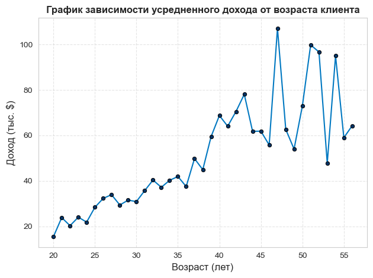

```python
sns.set_style("whitegrid")
palette = sns.color_palette("husl", 8)

sns.lineplot(data=df,
             x='age',
             y='income',
             errorbar=None,
             # estimator=None,
             # palette=palette,
             color='#0078c1',
             # hue=None,
             marker='o',
             markerfacecolor='#003366',
             markersize=4.5,
             markeredgecolor='black'
             )

# sns.histplot(x=df['age'], y=df['default'])

plt.xlabel('Возраст (лет)', fontsize=12)
plt.ylabel('Доход (тыс. $)', fontsize=12)
plt.title('График зависимости усредненного дохода от возраста клиента', fontsize=12, fontweight='bold')
# plt.legend(title="Доход", fontsize=10, title_fontsize=12)
plt.grid(True, linestyle='--', alpha=0.5)

# plt.ylim(0, df['income'].max())

plt.tight_layout()


# этот код сохраняет картинку для отправки ДЗ
plt.savefig(
    os.path.join(path_to_save_images, f'{image_name_prefix}_image_1.png')
)
```

## (2) (bar plot или stacked bar plot)

```python
education_labels = {
    1: "Начальное",
    2: "Среднее",
    3: "Среднее спец.",
    4: "Высшее",
    5: "Аспирантура"
}
df["ed_label"] = df["ed"].map(education_labels)
```

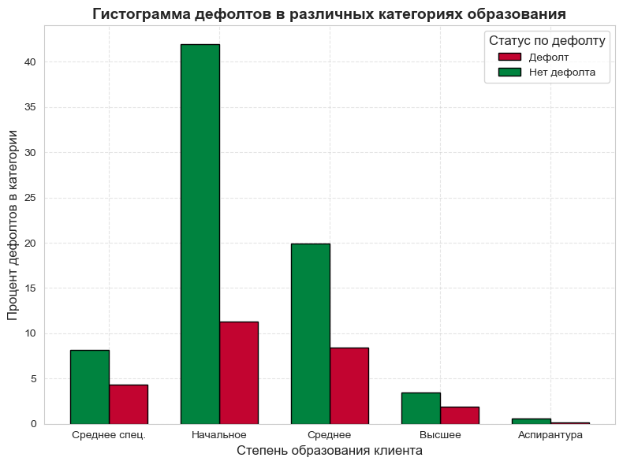

```python
plt.figure(figsize=(8, 6))

sns.histplot(data=df,
             x='ed_label',
             multiple='dodge',
             hue='default',
             stat="percent",
             palette=['#00833f', '#c20430'],
             discrete=True,
             shrink=0.7,
             alpha=1,
             edgecolor='black'
            )

plt.xlabel('Степень образования клиента', fontsize=12)
plt.ylabel('Процент дефолтов в категории', fontsize=12)
plt.title('Гистограмма дефолтов в различных категориях образования', fontsize=14, fontweight='bold')
plt.legend(title="Статус по дефолту", labels=['Дефолт', 'Нет дефолта'], fontsize=10, title_fontsize=12)
plt.grid(True, linestyle='--', alpha=0.5)

plt.tight_layout()

# этот код сохраняет картинку для отправки ДЗ
plt.savefig(
    os.path.join(path_to_save_images, f'{image_name_prefix}_image_2.png')
)
```

## (3) (hist plot или pair plot или kde plot)

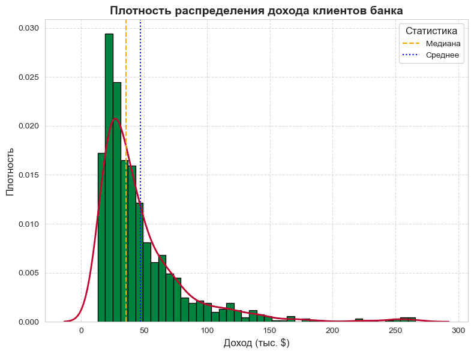

```python
plt.figure(figsize=(8, 6))

sns.histplot(data=df,
             x='income',
             kde=True,
             edgecolor="black",
             alpha=1,
             shrink=1,
             stat="density",
             color='#00833f'
            )

sns.kdeplot(data=df, x='income', color="#c20430", linewidth=2)

plt.axvline(df['income'].median(), color='orange', linestyle='--', label='Медиана')
plt.axvline(df['income'].mean(), color='blue', linestyle=':', label='Среднее')

plt.xlabel('Доход (тыс. $)', fontsize=12)
plt.ylabel('Плотность', fontsize=12)
plt.title('Плотность распределения дохода клиентов банка', fontsize=14, fontweight='bold')
plt.grid(True, linestyle='--', alpha=0.7, linewidth=0.8)
plt.legend(title="Статистика", fontsize=10, title_fontsize=12)
plt.tight_layout()

# этот код сохраняет картинку для отправки ДЗ
plt.savefig(
    os.path.join(path_to_save_images, f'{image_name_prefix}_image_3.png')
)
```

### Выводы (3):

Клиентов с доходами до 50 тыс. долл. значительно больше в выборке, чем клиентов более обеспеченных.

## (4) heatmap plot

```python
df = df.drop('ed_label', axis=1)
```

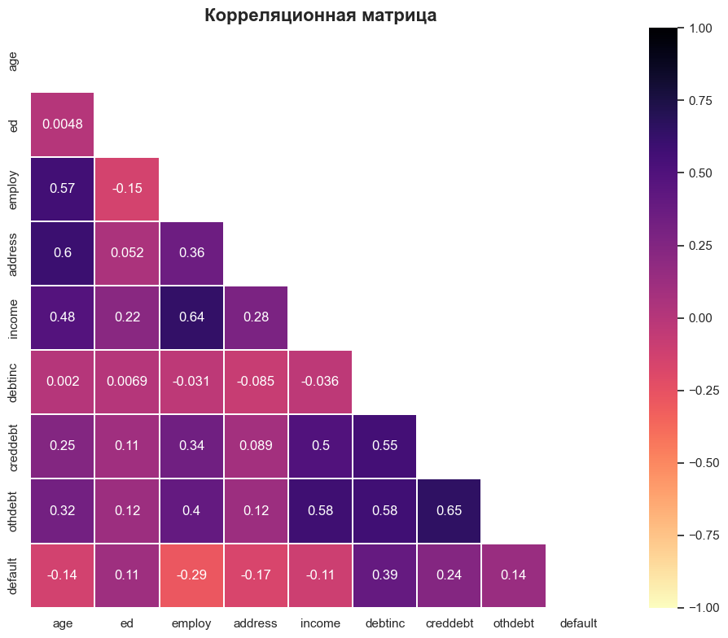

```python
corr_matrix = df.corr()
sns.set(style="white")

plt.figure(figsize=(10, 8))

mask = np.triu(np.ones_like(corr_matrix, dtype=bool))

sns.heatmap(corr_matrix,
            annot=True,
            cmap='magma_r',
            # fmt='.2f',
            linewidths=0.3,
            mask=mask,
            vmin=-1,
            vmax=1,
            linecolor='white',
            square=True)
plt.title('Корреляционная матрица', fontsize=16, fontweight='bold')

# Подпись не переносится на image при сохранении, так как частично не влезает во фрейм... Как идею на будущее оставил.

# plt.figtext(0.15, -0.005, "Светлый - сильная отрицательная корреляция, Темный - сильная положительная",
#             fontsize=12,
#             fontstyle='italic',
#             fontweight='bold')

plt.tight_layout()

# этот код сохраняет картинку для отправки ДЗ
plt.savefig(
    os.path.join(path_to_save_images, f'{image_name_prefix}_image_4.png')
)
```

### Выводы (4):

Ожидаемо, признаки с наиболее высоким коэффициентом корреляции - доход / количество лет стажа / возраст; скоррелированы разные виды задолженностей (некоторые являются производными друг от друга). Количество лет проживания по текущему адресу и возраст - интересная, бесспорно, корреляция, но в целом, логика за этим действительно присутствует.

## (5) plot на ваш выбор

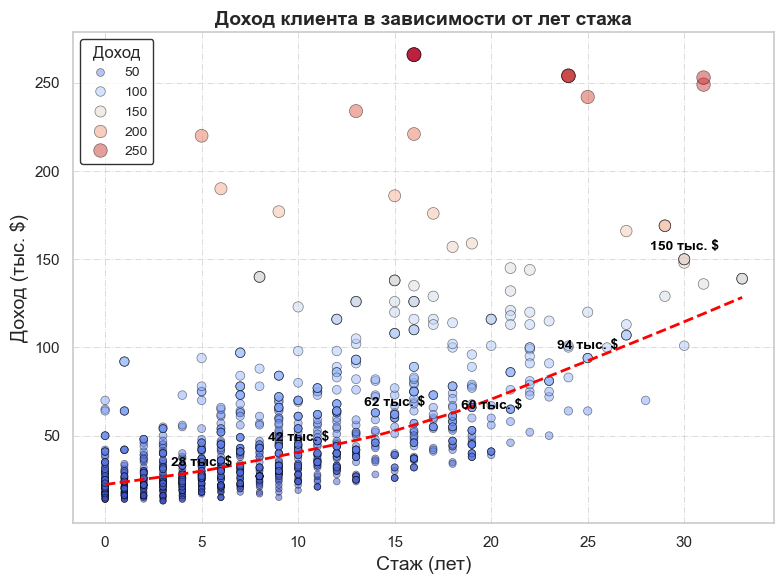

```python
# plt.figure(figsize=(6, 5))
plt.figure(figsize=(8, 6))


sns.set_style("whitegrid")
palette = sns.color_palette("coolwarm", as_cmap=True)


sns.scatterplot(data=df,
                x='employ',
                y='income',
                hue='income',
                palette=palette,
                size="income",
                sizes=(20, 100),
                s=80,
                alpha=0.5,
                edgecolor="black",
                linewidth=0.5
                # marker='o'
)

sns.regplot(data=df,
            x='employ',
            y='income',
            scatter=False,
            # order=2,
            lowess=True,
            # lowess=True,
            color='red',
            line_kws={'linewidth': 2, 'linestyle': '--'})

# sns.stripplot(data=df, x='employ', y='income', jitter=True, alpha=0.3)

key_points = [5, 10, 15, 20, 25, 30]
for iter in key_points:
    median_income = df[df['employ'] == iter]['income'].median()
    plt.text(iter, median_income + 5, f"{int(median_income)} тыс. $", fontsize=10, ha='center', color='black', fontweight='bold')
# plt.axvline(x, linestyle='--', color='gray', alpha=0.5)

plt.title('Доход клиента в зависимости от лет стажа', fontsize=14, fontweight='bold')
plt.xlabel('Стаж (лет)', fontsize=14)
plt.ylabel('Доход (тыс. $)', fontsize=14)
# plt.xticks(fontsize=10)
# plt.yticks(fontsize=10)


plt.grid(True, linestyle='-.', linewidth=0.7, alpha=0.7)
# plt.grid(True, which='both', linestyle='--', alpha=0.5)
plt.legend(title="Доход", fontsize=10, title_fontsize=12, frameon=True, edgecolor="black", facecolor="white")

plt.tight_layout()

# этот код сохраняет картинку для отправки ДЗ
plt.savefig(
    os.path.join(path_to_save_images, f'{image_name_prefix}_image_5.png')
)
```

### Выводы (5):

Заметна окололинейная (скорее, нелинейная) зависимость между стажем клиента в годах и его доходом. Чем более опытный работник клиент - тем больше он имеет заработок. Моделируя аппроксимирующую линюю, между сглаживанием и 2-ой степенью полиномиальности, выбрал сглаживание.

## Итоговый вывод по всему датасету (по всему EDA)

- В целом, значимых проблем в будущем при построении скоринговой модели не обнаружено;
- Можно отметить, что на данный момент у нас крайне мало признаков для моделирования;
- Было бы неплохо получить скоринговые метрики и добавить их в модель в будущем (ECL/PD/EAD/LGD);
- Особый интерес представляют клиенты с крайне высоким уровнем дохода. Необходимо выявить некую эвристику для работы с данной группой клиентов банка, так как использование их в модели напрямую будет вносить существенное смещение в наши итоговые оценки.